# Point Process Homework (Intensity and K Functions)

Instructions: Answer the following questions and write your answers in a word processor. Mathematical symbols should be written using the equation editor. Appropriate graphics should be included. The document may also be created in LaTeX, though this is NOT encouraged.

# Problem 1

The **spatstat** package includes a data set named `japanesepines`. The data give the locations of Japanese black pine saplings in a square sampling region in a natural forest. The observations were originally collected by Numata (1961).

1. Construct a plot of $L^(h)−h$ versus $h$ for the data with 95% tolerance envelopes. Use $Nsim=499$ simulated data sets to construct the envelopes. You do not need to specify `r` (the vector of distances) in the function; simply use the default values. Part A

[output not shown]

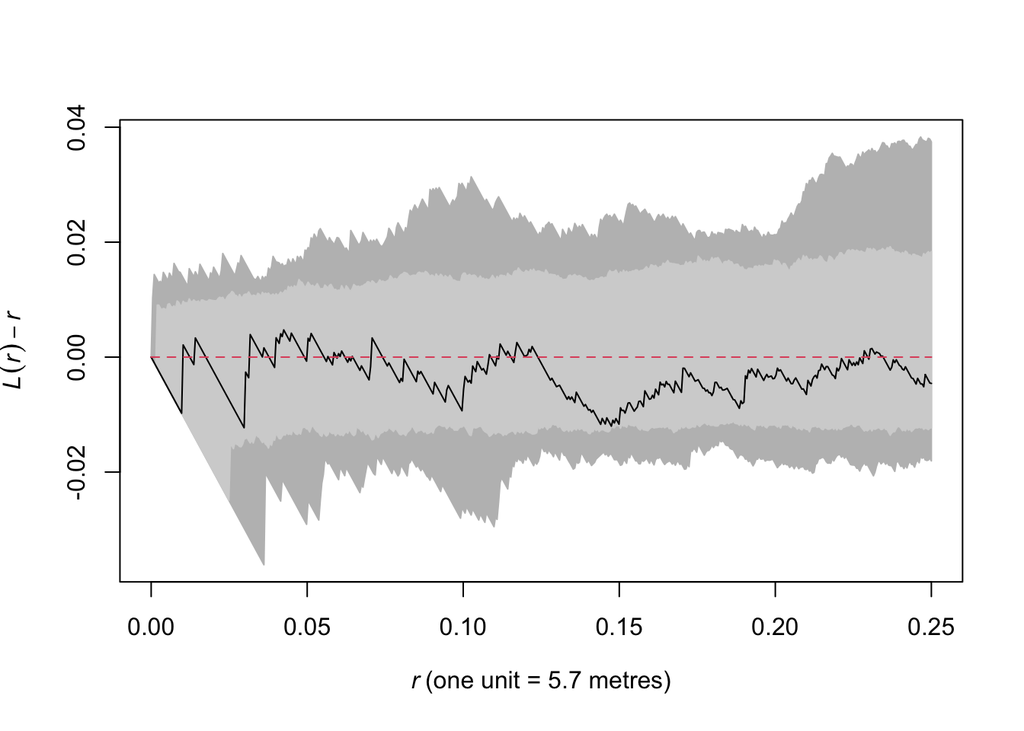

```r
library(spatstat)
lplot <- function(x, nsim = 499, level = 0.95,
                  correction = "Ripley", ...) {
  e_outer = envelope(x, fun = spatstat.explore::Lest,
                     nsim = nsim, nrank = 1,
                     savepatterns = TRUE)
  e_tol = envelope(e_outer, fun = spatstat.explore::Lest,
                   nsim = nsim,
                   nrank = floor((1 - level) * (nsim + 1)/2))
  plot(e_outer, fmla = . - r ~ r, legend = FALSE, main = "")
  plot(e_tol, fmla = . - r ~ r, shadecol = "lightgrey", add = TRUE)
}

data <- japanesepines
lplot(data)
```

2. Using the previous plot, what do you conclude about the data’s compability with CSR? Are there scales for which the event locations seem to exhibit more clustering than expected for a CSR process? Or more regularity than expected for a CSR process? Part B

3. Perform a hypothesis test to determine whether there is evidence of a departure from CSR by the data set at a significance level of 0.05 at some spatial scale between 0 and 0.25. Use $Nsim=499$ simulated data sets to compute your Monte Carlo p-values. What is your conclusion? Part C

```r
set.seed(1)
n <- data$n
r <- seq(0, .25, len = 201)
lambda <- intensity(data)
Tobs <- max(spatstat.explore::Lest(data, r = r, correction = "Ripley")$iso - r)
Tsim <- pbapply::pbsapply(1:499, FUN = function(i) {
  sim <- rpoispp(lambda)
  max(Lest(sim, r = r, correction = "Ripley")$iso - r)
})
mean(c(Tsim, Tobs) >= Tobs)
```

```
[1] 0.84
```

# Problem 2

Repeat the analysis from problem 1 for the `redwood` data in the **spatstat** package. The data represent the locations of 62 seedlings and saplings of California redwood trees in a square sampling region. They originate from Strauss (1975); the present data are a subset extracted by Ripley (1977) in a subregion that has been rescaled to a unit square. The coordinates are rounded to the nearest 0.01 units, except for one point which has an x coordinate of 0.999, presumably to ensure that it is properly inside the window.

1. Plot the data. Comment on what you see and whether this looks compatible with CSR. Part A

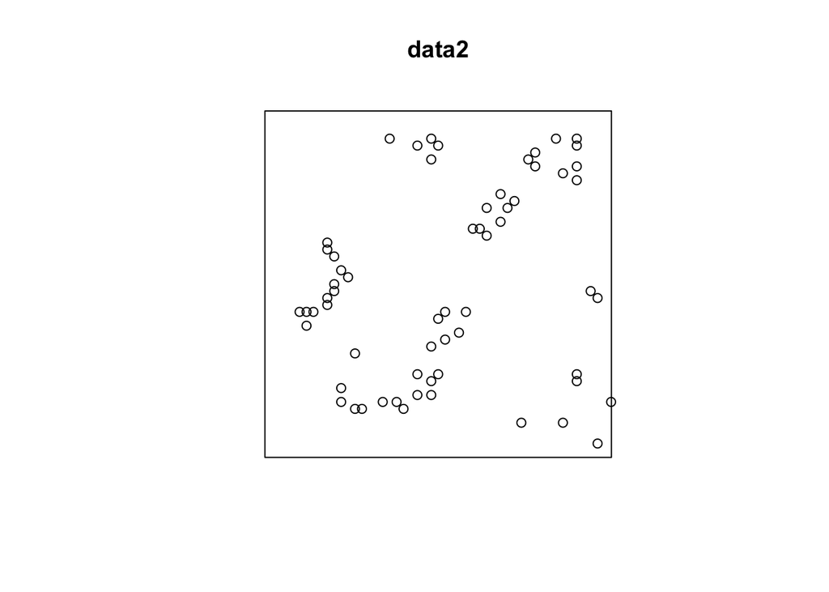

```r
data2 <- redwood
plot(data2)
```

1. Estimate and create a contour plot of the intensity function (use Scott’s rule for the bandwidth in each direction). Comment on the plot in relation to potential departures from CSR. Part B

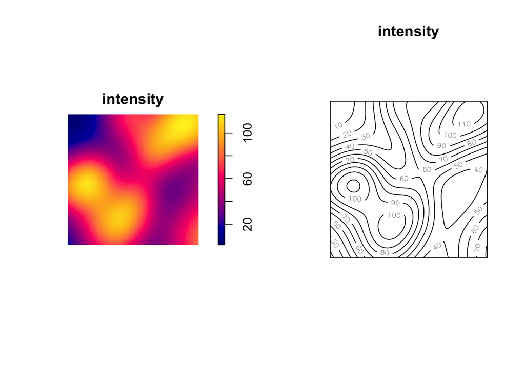

```r
scott <- bw.scott(data2)

intensity <- density(data2, sigma = c(scott[1], scott[2]))
par(mfrow = c(1, 2))
plot(intensity)
contour(intensity)
```

Looking at this we can definitely look at some areas where we see concentrated points especially in the top right and that middle left section. However, some of these changes aren’t exactly immediate.

1. Construct a plot of $L^(h)−h$ versus $h$ for the data with 95% tolerance envelopes. Use $Nsim=499$ simulated data sets to construct the envelopes. You do not need to specify `r` (the vector of distances) in the function; simply use the default values. Part C

[output not shown]

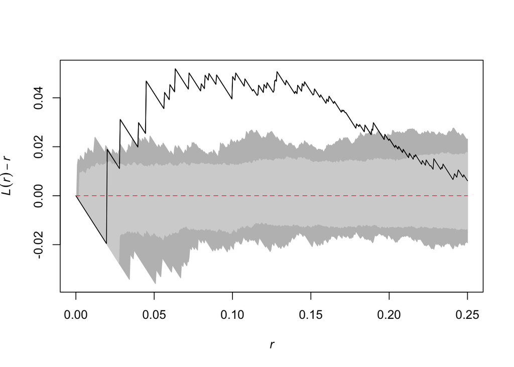

```r
lplot(data2)
```

1. Using the previous plot, what do you conclude about the data’s compability with CSR? Are there scales for which the event locations seem to exhibit more clustering than expected for a CSR process? Or more regularity than expected for a CSR process?
2. Perform a test to determine whether there evidence of a departure from CSR by the data set at a significance level of 0.05 at some spatial scale between 0 and 0.25. What is your conclusion? Use $Nsim=499$ simulated data sets to compute your Monte Carlo p-values. Part D

```r
n <- data2$n
r <- seq(0, 0.25, len = 201)
Tobs <- max(spatstat.explore::Lest(data2, r = r, correction = "Ripley")$iso - r)
Tsim <- pbapply::pbsapply(1:499, FUN = function(i) {
  sim <- rpoispp(lambda)
  max(Lest(sim, r = r, correction = "Ripley")$iso - r)
})
mean(c(Tsim, Tobs) >= Tobs)
```

```
[1] 0.002
```

Thus we reject the null hypothesis under CSR since we have a p value of .002 which is a very strong indicator we do not have CSR.

# Problem 3

Run the following code to generate some event locations in one-dimension.

```r
set.seed(1)
x <- runif(15)
```

Now define `h` in the following way:

```r
h <- seq(-1, 2, len = 1000)
```

We will now visualize the process of density estimation for two different bandwidths. Note that we are technically not constructing densities because we are not scaling correctly.

1. Complete the following tasks.
   1. For each event location, evaluate the Gaussian kernel function (this is simply `dnorm`) at each value of `h` using the event location as the `mean` argument and with a `sd` argument of 0.10.
   2. For each value of `h`, sum the evaluated kernel values across all 15 event locations.
   3. Create a plot that displays the sum of the evaluated kernel functions on the y-axis and the value of `h` on the x-axis. On this plot, overlay the evaluated kernel function for each event location as a function of `h`.

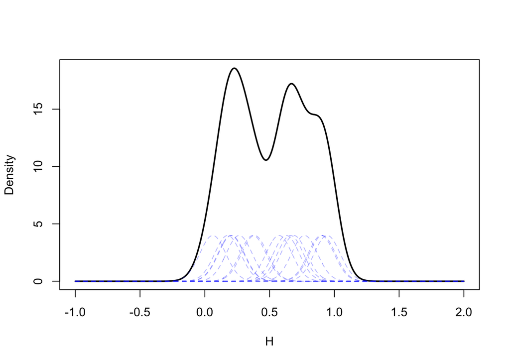

```r
gausian <- sapply(x, function(dnorm){
  dnorm(h, mean = dnorm, sd = .10)})
sum_gausian <- rowSums(gausian)
plot(h, sum_gausian, type = "l", lwd = 2,
     ylab = "Density", xlab = "H")

matlines(h, gausian, lty = 2, col = rgb(0, 0, 1, 0.3))
```

2. Repeat the same process as (a) using a `sd`/bandwidth of 0.25.

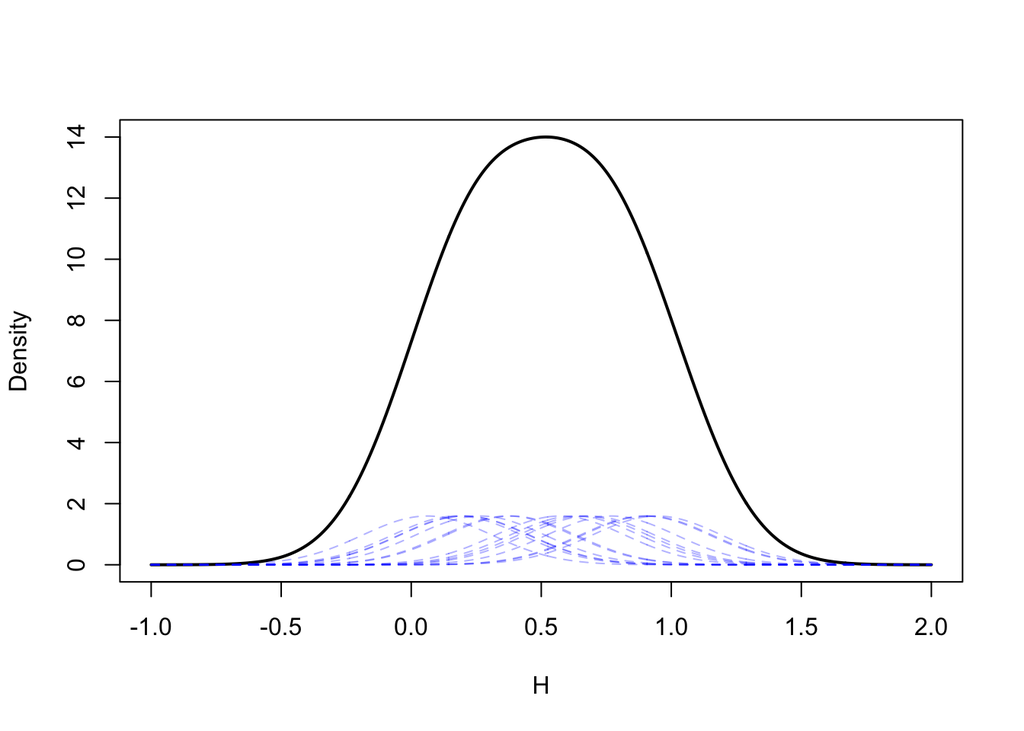

```r
gausian <- sapply(x, function(dnorm){
  dnorm(h, mean = dnorm, sd = .25)})
sum_gausian <- rowSums(gausian)
plot(h, sum_gausian, type = "l", lwd = 2,
     ylab = "Density", xlab = "H")

matlines(h, gausian, lty = 2, col = rgb(0, 0, 1, 0.3))
```

3. What is the relationship between bandwidth and the smoothness of the estimated density?

The higher the bandwidth the smoother the estimated density is. To prove this to myslef I ran it again but with an even higher SD.

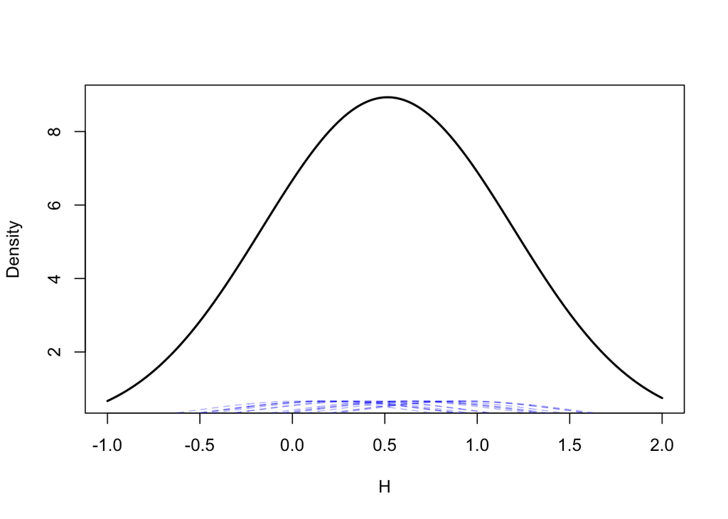

```r
gausian <- sapply(x, function(dnorm){
  dnorm(h, mean = dnorm, sd = .60)})
sum_gausian <- rowSums(gausian)
plot(h, sum_gausian, type = "l", lwd = 2,
     ylab = "Density", xlab = "H")

matlines(h, gausian, lty = 2, col = rgb(0, 0, 1, 0.3))
```